# Ammonia Analysis

In this project we want to analyse the factors that impact the percentage of ammonia in a chemical plant.

The ammonia oxidates to nitric acid, therefore we want the less percentage of ammonia as possible.

In order to answer this question we need to analyse if there is evidence that the percentage of ammonia is related to the other variables.

To do so, I will check if

1. Is there evidence that the percentage of ammonia is related to temperature, after controling for time?
2. Is there evidence that the percentage of ammonia is related to acid concentration, after controling for both time and temperature?
3. Is there evidence that a model with concentration, time and temperature is better than a model with just and intercept.

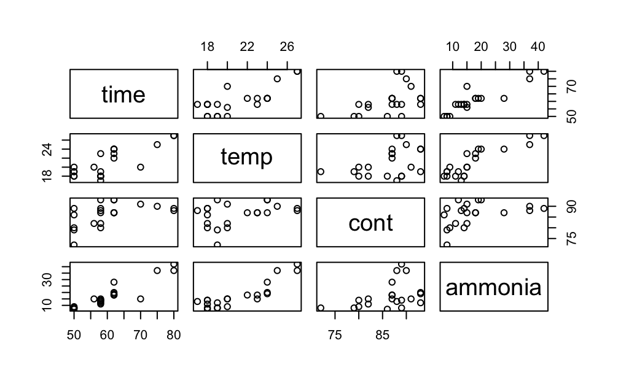

```r
#setting the working directory
setwd("~/Desktop/unsw/Projects/Amonia_analysis")
#loading the data
ammonia=read.csv("ammonia.csv")
#plotting the data in pairs
pairs(ammonia)
```

From the pairs plot, it seems to be a linear relationship between ammonia and time, ammonia and temperature. And also, from the pairs plot it doesnt seem to exist a multicolinearity problem.

To answer the questions we will construct a linear regression where ammonia is the response variable and time+temperature+concentration are the predictor variables. Since we will use ANOVA to answer those questions, the order of the predictors will influece the results.

Next, we create a linear model and check the plots to identify if the assumptions a the linear model are met. We need to check that the errors (and hence the response): - have constant variance - are normally distributed - are linear

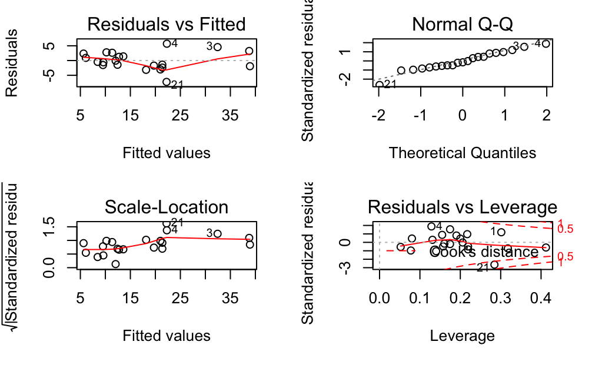

```r
#creating linear model
model=lm(ammonia~time+temp+cont,data=ammonia)
#specifying position of plots
par(mfrow=c(2,2))
#plotting the model
plot(model)
```

From the first (Residuals X Fitted values) and the third ($\sqrt{Standardizes residuals}$ X Fittws values) plot we can se that the constante variance assumption is not met. We look for a fan shape in plot 1 and an increasing shape in plot 3 which indicated failure in this assumption.

From the first plot we also see that the linearity assumption is met. Here we look for a U shape that indicates that the assumption is failed (which is not the case).

It is also important to notice the existance of an influential observation that is clear from plot 4 (Standardizes residuals X Leverage). The deletion of the influential observation from the data may change the outcome of the regression, therefore influential obervations may be careful analysed.

Now we want to fix the violation of the constant variance assumption. We do that by log transforming the response variable (ammonia).

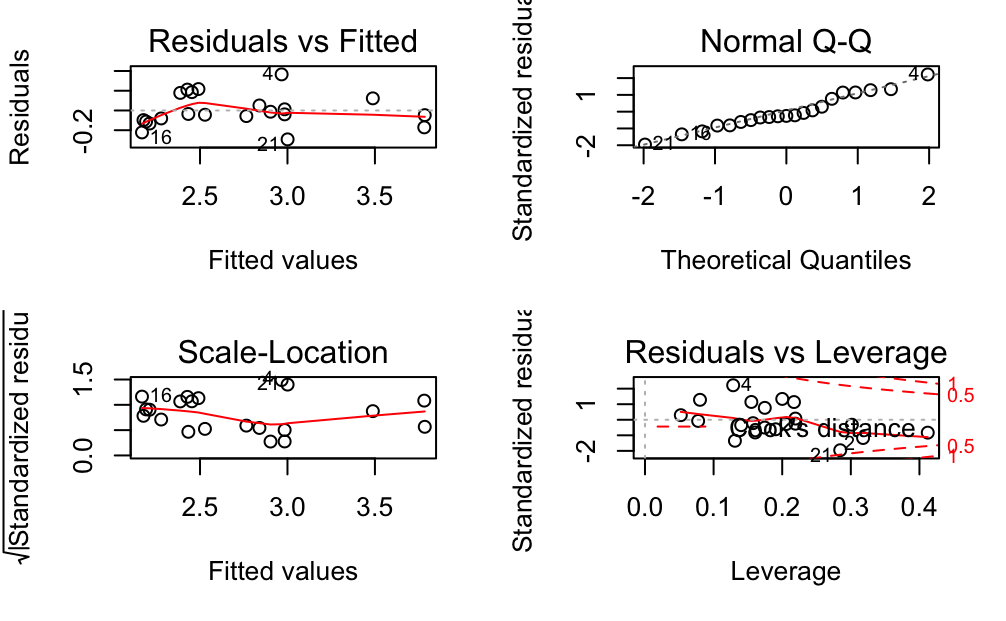

```r
#linear regression of transformed model
model_log = lm(log(ammonia)~time+temp+cont,data=ammonia)
#specifying position of plots
par(mfrow=c(2,2))
#plotting the model
plot(model_log)
```

Now the variance seems to be fixed and there is no influential observation anymore. However, the linearity assumption is now violated, as we can see from the first plot a U shape trend on the residuals.

We plot the partial residuals in order to find out which predictors does not have a linear relationship and may be causing impacting on the linearity assumption.

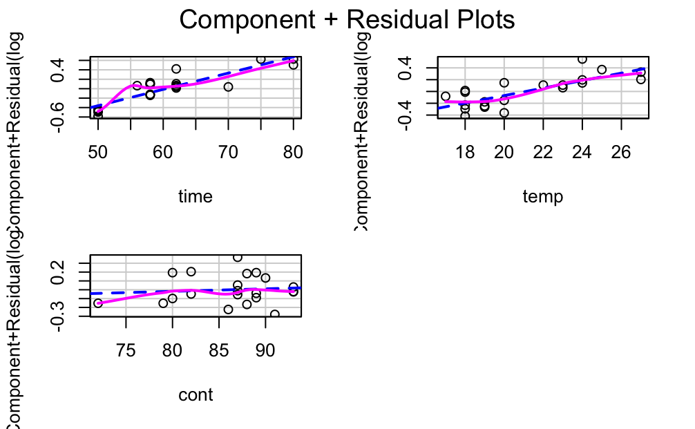

```r
#loeading the car package
library(car)
#component + residual plots
crPlots(model_log)
```

We want the purple lines to be as close to the blue lines as possible to indicate that the predictor analysed is linearly related to the response. It is possible that the time predictor is nor linearly related to the response (ammonia), as we can see from the first plot. To fix the failure on the linearity assumption we can try to transform this predictor (time) into its quadratic. Hence,

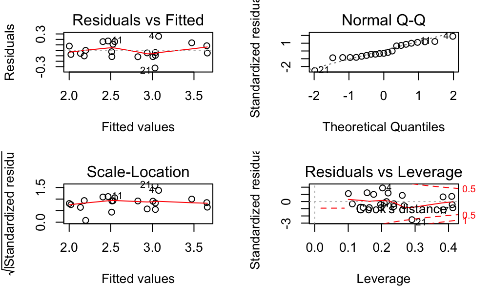

```r
ammonia$time2=ammonia$time^2
model_quadr=lm(log(ammonia)~time+time2+temp+cont,data=ammonia)
par(mfrow=c(2,2))
plot(model_quadr)
```

Now both linearity and constant variance assumptions looks satisfied as well as normality of the errors. Therefore, the final model is log(ammonia)~time+time2+temp+cont.

# Question 1

1. Is there evidence that the percentage of ammonia is related to temperature, after controling for time?

Using statistical terms, we want to test the hyopthesis:

So if the null hypothesis is true, there is no evidence that the percentage of ammonia is related to temperature, after controling for time.

We test the hypothesis using the anova table bellow:

```r
anova(model_quadr)
```

```
Analysis of Variance Table

Response: log(ammonia)
          Df Sum Sq Mean Sq  F value    Pr(>F)
time       1 4.6352  4.6352 199.9078 1.848e-10 ***
time2      1 0.1039  0.1039   4.4806  0.050303 .
temp       1 0.3568  0.3568  15.3892  0.001214 **
cont       1 0.0148  0.0148   0.6392  0.435725
Residuals 16 0.3710  0.0232
---
Signif. codes:  0 ‘***’ 0.001 ‘**’ 0.01 ‘*’ 0.05 ‘.’ 0.1 ‘ ’ 1
```

From the anova table, it is clear that: F=15.3892 and p=0.001214. Using a 5% significance leve we have strong evidence against the null hypothesis. Hence we reject the null hypothesis and accept the alternative hypothesis, which means that the percentage of ammonia is related to temperature after controling for time, since p<0.05.

# Question 2

2. Is there evidence that the percentage of ammonia is related to acid concentration, after controling for both time and temperature?

Using statistical terms, we want to test the hyopthesis:

$H_0:\beta_{cont}=0$

$H_1:\beta_{cont}\ne0$

So if the null hypothesis is true, there is no evidence that the percentage of ammonia is related to acid concentration, after controling for both time and temperature.

Here we could use both summary table and anova table. Both tables will give the same result if we have this model on the anova table: log(ammonia)~time+time2+temp+cont. The concentration term needs to be the last term of the model since we want to check if ammonia’s percentage is related to $\textbf{concentration}$ after controling for time and temperature.

We can compare the results given by both tables, and it should present the p value for concentration.

```r
anova(model_quadr)
```

```
Analysis of Variance Table

Response: log(ammonia)
          Df Sum Sq Mean Sq  F value    Pr(>F)
time       1 4.6352  4.6352 199.9078 1.848e-10 ***
time2      1 0.1039  0.1039   4.4806  0.050303 .
temp       1 0.3568  0.3568  15.3892  0.001214 **
cont       1 0.0148  0.0148   0.6392  0.435725
Residuals 16 0.3710  0.0232
---
Signif. codes:  0 ‘***’ 0.001 ‘**’ 0.01 ‘*’ 0.05 ‘.’ 0.1 ‘ ’ 1
```

Analysing using the anova table: F=0.6392 and p=0.435725. Therefore, we accept the null hypothesis, which meas that we are 95% confident that there is no evidence that the percentage of ammonia is related to acid concentration, after controling for both time and temperature.

```r
summary(model_quadr)
```

```
Call:
lm(formula = log(ammonia) ~ time + time2 + temp + cont, data = ammonia)

Residuals:
     Min       1Q   Median       3Q      Max
-0.32335 -0.09162 -0.04033  0.11255  0.25697

Coefficients:
              Estimate Std. Error t value Pr(>|t|)
(Intercept) -4.7186027  1.5433711  -3.057  0.00752 **
time         0.1754787  0.0541513   3.241  0.00512 **
time2       -0.0010852  0.0004142  -2.620  0.01856 *
temp         0.0689005  0.0174023   3.959  0.00112 **
cont        -0.0065290  0.0081667  -0.799  0.43572
---
Signif. codes:  0 ‘***’ 0.001 ‘**’ 0.01 ‘*’ 0.05 ‘.’ 0.1 ‘ ’ 1

Residual standard error: 0.1523 on 16 degrees of freedom
Multiple R-squared:  0.9323,    Adjusted R-squared:  0.9154
F-statistic:  55.1 on 4 and 16 DF,  p-value: 3.722e-09
```

# Question 3

3. Is there evidence that a model with concentration, time and temperature is better than a model with just and intercept.

Here we want to test the hypothesis:

At this point, we can use both anova and summary tables as well, with a slighlty change on the model in anova.

Using the summary table, we get:

```r
summary(model_quadr)
```

```
Call:
lm(formula = log(ammonia) ~ time + time2 + temp + cont, data = ammonia)

Residuals:
     Min       1Q   Median       3Q      Max
-0.32335 -0.09162 -0.04033  0.11255  0.25697

Coefficients:
              Estimate Std. Error t value Pr(>|t|)
(Intercept) -4.7186027  1.5433711  -3.057  0.00752 **
time         0.1754787  0.0541513   3.241  0.00512 **
time2       -0.0010852  0.0004142  -2.620  0.01856 *
temp         0.0689005  0.0174023   3.959  0.00112 **
cont        -0.0065290  0.0081667  -0.799  0.43572
---
Signif. codes:  0 ‘***’ 0.001 ‘**’ 0.01 ‘*’ 0.05 ‘.’ 0.1 ‘ ’ 1

Residual standard error: 0.1523 on 16 degrees of freedom
Multiple R-squared:  0.9323,    Adjusted R-squared:  0.9154
F-statistic:  55.1 on 4 and 16 DF,  p-value: 3.722e-09
```

So F-statistic= 55.1 and p-value=3.722e-09. There is strong evidence against the null hypothesis, so we reject the null hypothesis and accept the alternative hypothesis. Hence, we are 95% confident that a model with concentration, time and temperature is better than a model with just and intercept.

Using the anova table, we need to compare a model with only the intercept and a model with the predictors:

```r
null_mod=lm(formula = log(ammonia) ~ 1, data = ammonia)
anova(null_mod,model_quadr)
```

```
Analysis of Variance Table

Model 1: log(ammonia) ~ 1
Model 2: log(ammonia) ~ time + time2 + temp + cont
  Res.Df    RSS Df Sum of Sq      F    Pr(>F)
1     20 5.4817
2     16 0.3710  4    5.1107 55.104 3.722e-09 ***
---
Signif. codes:  0 ‘***’ 0.001 ‘**’ 0.01 ‘*’ 0.05 ‘.’ 0.1 ‘ ’ 1
```

F=55.1 and p-value=3.722e-09 and we get the same conclusion as we got using the summary table.